# Social Network Analysis Workshop

# What does SNA Data Look Like?

Data for SNA is ultimately just relational data; if you have a list of Xs interacting with Ys, you have network data. However, there are two main ways to represent that data to be useful in SNA using R.

## Adjacency Matrix

An **adjacency matrix** is a matrix with each node in your network represented as a row and column. If two nodes are connected, a one is put into the matrix where they intersect, if they do not, the value is zero. The sender nodes are the rows, and the receiver nodes are the columns. It is possible to weight connections (i.e. have a 2 or 3 represent multiple connections, but it is not well supported.)

```r
am = as.sociomatrix(e.d)
colnames(am) = letters[1:length(colnames(am))]
row.names(am) = letters[1:length(row.names(am))]
knitr::kable(am)
```

|  | a | b | c | d | e | f | g | h | i | j |
| --- | --- | --- | --- | --- | --- | --- | --- | --- | --- | --- |
| a | 0 | 1 | 0 | 0 | 0 | 0 | 0 | 0 | 0 | 0 |
| b | 0 | 0 | 0 | 1 | 0 | 0 | 1 | 0 | 0 | 0 |
| c | 1 | 0 | 0 | 0 | 1 | 0 | 0 | 0 | 1 | 1 |
| d | 0 | 0 | 0 | 0 | 1 | 0 | 0 | 1 | 1 | 0 |
| e | 0 | 1 | 0 | 0 | 0 | 0 | 0 | 0 | 0 | 0 |
| f | 0 | 1 | 0 | 0 | 0 | 0 | 0 | 0 | 0 | 0 |
| g | 0 | 0 | 0 | 0 | 0 | 1 | 0 | 0 | 0 | 0 |
| h | 1 | 1 | 0 | 0 | 0 | 0 | 0 | 0 | 0 | 0 |
| i | 0 | 0 | 0 | 0 | 0 | 0 | 0 | 0 | 0 | 0 |
| j | 0 | 0 | 0 | 0 | 0 | 0 | 0 | 0 | 0 | 0 |

## Edgelist

An **edgelist** is a long matrix with two columns containing the unique names for your nodes. The first column is called **ego**, which contains who is sending the connection in a directed network. The second column is called **alter**, or who is receiving the connection. In an undirected network, you only need to include a connection in one direction, and it will always count as mutual. The columns do not need to be named ego and alter, but those are the common terms used in network research.

```r
el = as.data.frame(as.edgelist(e.d), stringsAsFactors = FALSE)
key = data.frame(id = 1:10, name = letters[1:10])
colnames(el) = c("ego", "alter")
el$ego = key[match(el[["ego"]], key[["id"]]), "name"]
el$alter = key[match(el[["alter"]], key[["id"]]), "name"]
knitr::kable(el)
```

| ego | alter |
| --- | --- |
| a | b |
| b | d |
| b | g |
| c | a |
| c | e |
| c | i |
| c | j |
| d | e |
| d | h |
| d | i |
| e | b |
| f | b |
| g | f |
| h | a |
| h | b |

Both of these data sets create the following network. Try comparing the data sets to the plot, looking at directionality specifically.

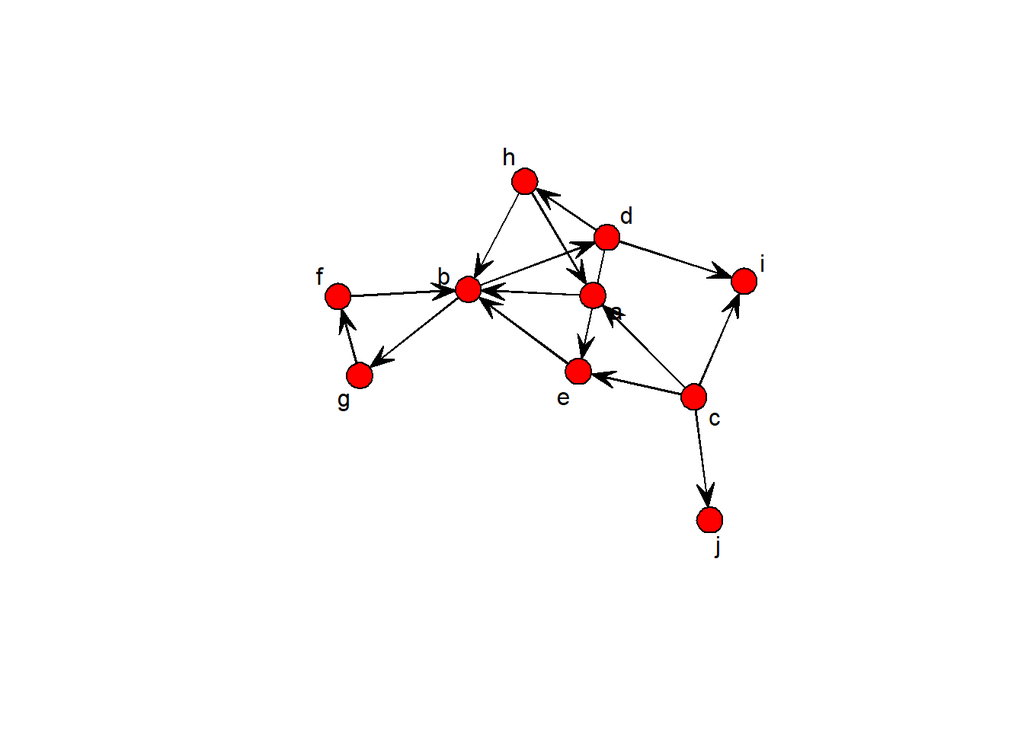

```r
e.d%v%"vertex.names" = letters[1:length(e.d%v%"vertex.names")]
plot(e.d, displaylabels = TRUE, label.pos = 0, arrowhead.cex = 3, vertex.cex = 3)
```

## Isolates and Largest Components

Regardless of how your data is formatted, it is likely that not all nodes will be connected to each other. Depending on how the data was collected, you may even have **isolates** in your data, or nodes that have no edges at all; these appear as lone dots in network graphs. There can also be multiple **components** or collection of nodes that are tied to each other. Even though they are not connected, these components are considered to be the same ‘network’ if they came from the same data.

Presented is a comparison between a total network, and he largest component:

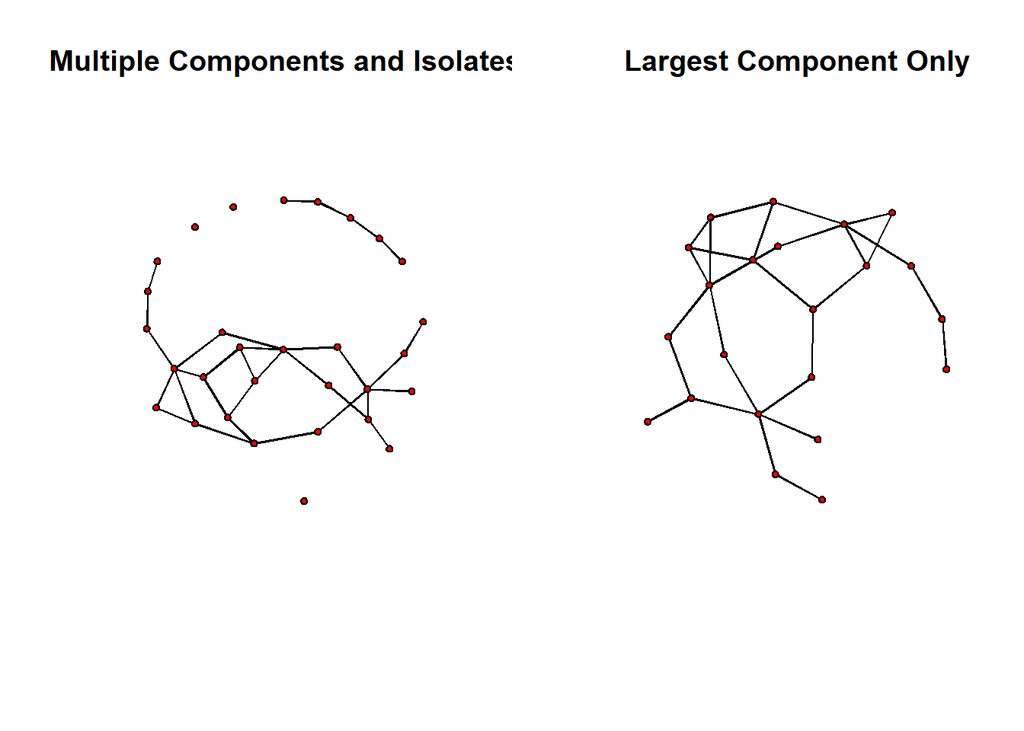

```r
set.seed(26)
com = rgraph(30, mode="graph", tprob = .08)
com = network(com, directed = FALSE)

capture.output({
lcom = com
lcom%v%"lc" = component.largest(lcom)
lcom = delete.vertices(lcom, which(lcom%v%"lc" == FALSE))
}, file = tempfile()) #These are just to silence some code output, remove them if you would like!

par(mfrow = c(1,2))
plot(com, main = "Multiple Components and Isolates")
plot(lcom, main = "Largest Component Only")
```

# What Can SNA Do?